# SCEM Final Coursework

Task I

Sangbin Lim (2747409)

## IMPORTANT NOTES:

- **DO NOT** change the code block names. Enter your solutions to each question into the predefined code blocks.
- **DO NOT** add calls to `install.packages()` or load any additional packages in your code blocks. Calls to `install.packages()` may result in zero marks for the activity where it happens.
- **DO NOT** load any additional packages. All packages allowed and required for this coursework are already loaded in the **Setup** code block. Use of other packages may result in execution errors when marking, which can result in zero marks for one or more activities.
- **Don’t forget to replace the placeholder value in code block “ID” by your valid student ID number.**
- Instructions for this task are provided in blue text below. Your solution should NOT be added within those text boxes, and should NOT be in blue text. **During marking, all the text within the text blocks below, with names starting with “prompt”, will be removed and not visible to the marker.**

```
##
## List of allowed packages (pre-loaded):
##  ggplot2
##  multcomp
##  devtools
##  dplyr
##  tidyr
##  knitr
##  ExpDE
```

In this task you will design, run, and analise an experiment comparing different configurations of the DE algorithm for a class of problems of interest. Here are the required statistical parameters for your experiment:

```
## Desired statistical parameters for your experimental design:
## ============================================================
## Significance level (alpha): alpha = 0.05
## Minimally relevant effect size (MRES): d* = 0.9
## Desired statistical power for MRES (desired power): (1-beta)* = 0.85
## Number of repeated runs for each method on each problem: nruns = 30
## ============================================================
```

Here are the methods you will compare in your experiment. You will be able to pass method names directly to the data-generating function later in this task.

```
## ============================================================
## Your experiment will compare 4 algorithm configurations
## Your selected methods are named:
## DE.2747409.A
## DE.2747409.B
## DE.2747409.C
## DE.2747409.D
## Each method can be passed by name as the argument method.name of function ExpDE2()
## If you want to inspect the specificities of each method, check the output list.
```

# Question 1.1

### 1.1.a.

Enter the statistical hypotheses of your initial (omnibus) test for this task in the text block below. Provide a brief (less than 150 words) description of what is being tested.

Our objective is to compare the mean loss of the optimisation methods (i.e. 4 algorithm configurations) on a single problem under repeated runs, and determine whether each method has a statistically significant effect on the mean loss. In particular, we aim to determine which method performs best for this problem. Since our goal is to minimise the loss, we use F-statistic from one-way ANOVA to test whether the variability in mean loss between method groups is significantly greater than the variability within the groups. Thus, rejecting the null hypothesis provides adequate statistical evidence that at least one method’s mean loss differs significantly from the others, thereby providing a rationale for conducting post-hoc tests to identify which method’s mean differ from each others.

$$\begin{cases}
H_0 &: \mu_i = \mu_j,\ \forall i, j \\
H_1 &: \exists\, i, j \text{ such that } \mu_i \ne \mu_j
\end{cases}$$

### 1.1.b.

The name of the problem you should use for this item is automatically generated and stored in a variable called `my.problem`.

Below is an example of how to generate a single observation for your first method on the test problem `my.problem`.

```r
## DO NOT CHANGE ANYTHING IN THIS CODE BLOCK
x <- ExpDE2(method.name = method.names[1], problem.name = my.problem)
my_obs <- log(x)
my_obs
## [1] 2.911511
```

Adapt this code to generate the necessary number of observations (defined in your experimental parameters) for all of your test methods. Store your observations in a tidy data frame named `myres`, containing one observation per row and the following columns:

- `Method` (containing the method name)
- `Value` (containing the observation)

Your data frame `myres` should have (nruns x number of methods) rows.

```r
set.seed(MY_STUDENT_ID) ## <--- DO NOT CHANGE THIS LINE

# ADD YOUR CODE HERE

nruns <- exp_pars$nruns

myres<- lapply(1:4, \(m){
  obs <- replicate(nruns,log(ExpDE2(method.name = method.names[m], problem.name = my.problem)))
  data.frame(Method = method.names[m], Value = obs)}) %>%
  bind_rows()

# Example of the first 6 rows in actual "myres" data frame (120 × 2).
head(myres)
##         Method    Value
## 1 DE.2747409.A 3.335777
## 2 DE.2747409.A 3.169443
## 3 DE.2747409.A 3.683226
## 4 DE.2747409.A 2.453439
## 5 DE.2747409.A 3.291326
## 6 DE.2747409.A 2.899134

## (DON'T FORGET THAT YOUR OBSERVATIONS SHOULD BE STORED IN A DATA FRAME CALLED
## myres WITH THE STRUCTURE DESCRIBED ABOVE).
```

### 1.1.c

Estimate the mean loss and associated parametric confidence interval (at the significance level provided in your experimental parameters) for all methods. Store your results in a single dataframe called `myCIs01`, with the following columns:

- `Method` (containing the method name)
- `Mean` (containing the sample estimate of the mean)
- `CI.lower` (containing the estimated lower bound of the confidence interval)
- `CI.upper` (containing the estimated upper bound of the confidence interval)

```r
# ADD YOUR CODE HERE

alpha <- exp_pars$alpha

myCIs01 <- myres %>%
  group_by(Method) %>%
  summarise(Mean = t.test(Value,conf.level = 1 - alpha)$estimate,
            CI.lower = t.test(Value,conf.level = 1 - alpha)$conf.int[1],
            CI.upper = t.test(Value,conf.level = 1 - alpha)$conf.int[2])

myCIs01
## # A tibble: 4 × 4
##   Method        Mean CI.lower CI.upper
##   <chr>        <dbl>    <dbl>    <dbl>
## 1 DE.2747409.A  3.18     3.06     3.30
## 2 DE.2747409.B  3.78     3.66     3.91
## 3 DE.2747409.C  4.15     4.10     4.20
## 4 DE.2747409.D  2.25     2.21     2.28

## (DON'T FORGET THAT YOUR OUTPUT OBJECT SHOULD BE STORED IN A VARIABLE CALLED
## myCIs01).
```

Generate a plot of the confidence intervals using ggplot2. You plot should have the methods on the y-axis and the values on the x-axis - something similar (not identical) to the figure in [this link](https://uob-my.sharepoint.com/:i:/g/personal/me24832_bristol_ac_uk/EYWqpYTKLd5IvNfo_Vy3H4MB1bFnZ2UxGOVfC9QPfLd2JA?e=b4HizP) (without the vertical dashed line):

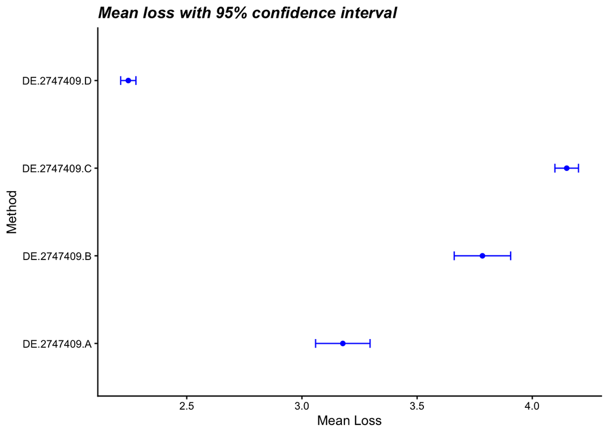

```r
# ADD YOUR CODE HERE

ggplot(myCIs01,aes(x = Mean, y = Method)) +
  geom_errorbar(aes(xmin = CI.lower, xmax = CI.upper), width = 0.1,colour = "blue") +
  geom_point(colour = "blue") +
  theme_classic() +
  ggtitle("Mean loss with 95% confidence interval")+
  xlab("Mean Loss") +
  theme(plot.title = element_text(face = "bold.italic"))
```

### 1.1.d Statistical testing

Use the code block below to perform the adequate statistical test, according to the instructions of the coursework descriptor. Store the statistical test object in a variable called `mytest01`. Echo the results of your test (using the `summary()` function, if applicable) to print the results.

```r
# ADD YOUR CODE HERE

myres$Method <- as.factor(myres$Method)

mytest01 <- aov(Value ~ Method, data = myres)
summary(mytest01)
##              Df Sum Sq Mean Sq F value Pr(>F)
## Method        3  62.23  20.743   353.8 <2e-16 ***
## Residuals   116   6.80   0.059
## ---
## Signif. codes:  0 '***' 0.001 '**' 0.01 '*' 0.05 '.' 0.1 ' ' 1

## (DON'T FORGET THAT THE OBJECT RETURNED BY THE STATISTICAL TEST FUNCTION
## SHOULD BE STORED IN A VARIABLE CALLED mytest01).
```

Add a comment in the text block below (up to 100 words) indicating if your results were statistically significant, based on the observed p-value and your predefined significance level.

Based on the one-way ANOVA test conducted to compare the mean loss of the methods, the result showed a very large F-statistic, F(3, 116) = 353.8, indicating that the variability between method groups is significantly greater than the variability within the groups. Furthermore, since the observed p-value (p < 2e-16) is less than the predefined significance level (alpha = 0.05), there is adequate statistical evidence that at least one method’s mean loss differs significantly from the others. Therefore, we reject the null hypothesis that all methods have the same mean loss.

### 1.1.e Checking assumptions

Provide a brief (less than 150 words) description and explanation of the statistical assumptions of the test used, as a bullet list:

- The residuals of the model are assumed to follow a Normal distribution with mean 0. Practically, this corresponds to assuming that the sampling distribution of the mean is approximately Normal. Therefore, we plot normal QQ-plots of the residuals to assess their normality.
- The variance of the residuals is assumed to be constant across method groups (homoscedasticity). Non-identical variance distribution indicate heteroscedasticity, under which the F-statistic from ANOVA can result to distorted p-values and misleading conclusions due to overly significant results and reduced ability to detect true effects (Type I error ↑, Power ↓). Therefore, we conduct Fligner-Kileen test to assess homoscedasticity.
- The residuals of the model are assumed to be independent within and across methods. Failure could result in biased standard errors and p-values. However, since our experiment is designed to be executed independently with a separate random seed, dependence of the residuals is not expected.

Generate residual plots which could be used to verify the remaining assumptions of your test (you can either use the default plotting methods of the statistical test, or generate the appropriate residual plots using, e.g., base R plots or ggplot2).

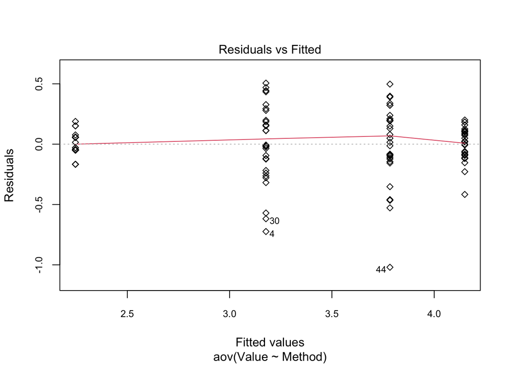

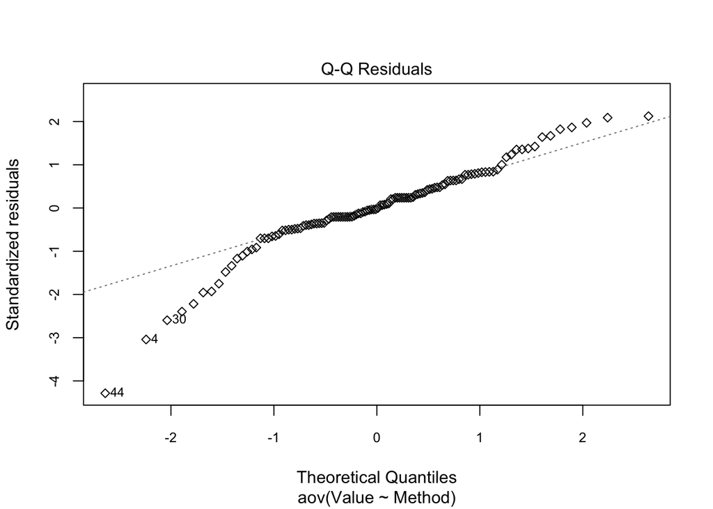

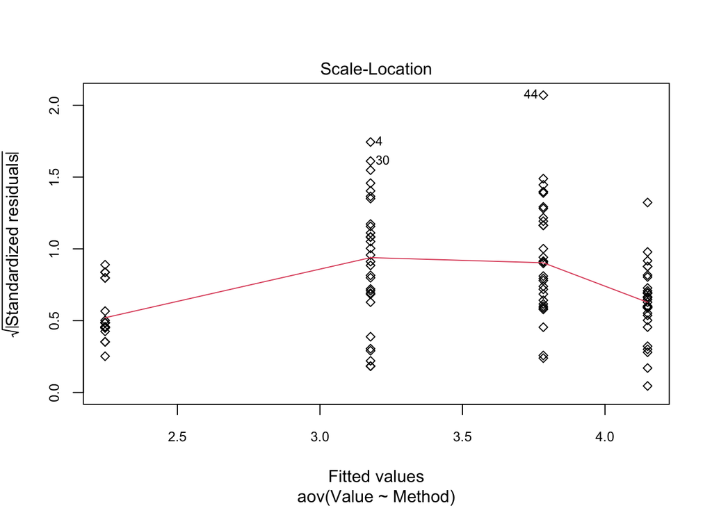

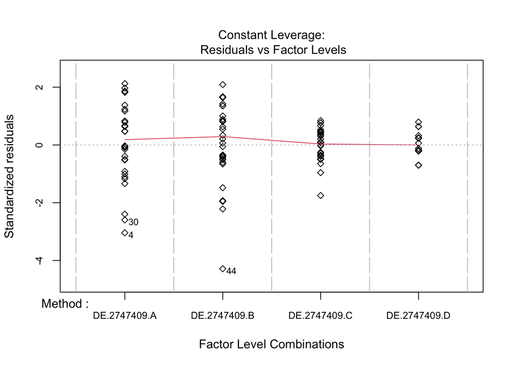

```r
# ADD YOUR CODE HERE

mytest_residual = mytest01$residuals

# Summary of the ANOVA assumptions
par(mfrow = c(1,1), cex.axis = 0.8)
plot(mytest01, pch = 5, cex = 0.8)
```

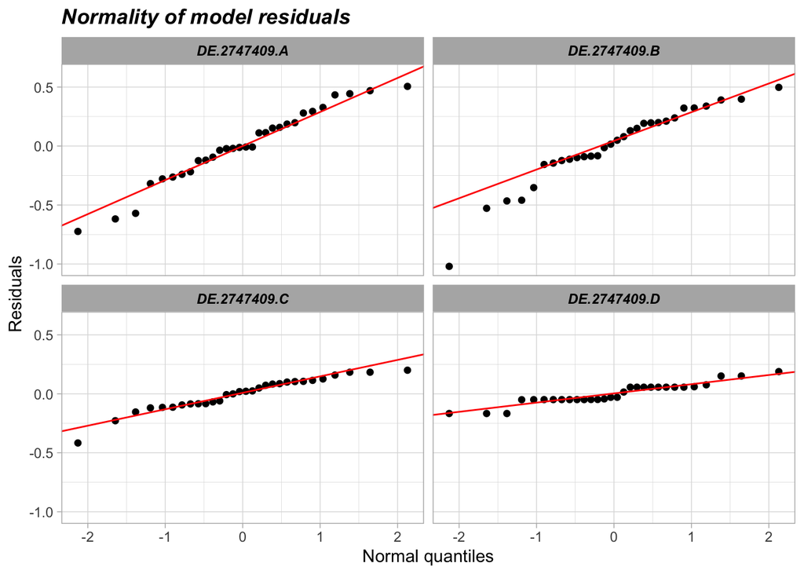

```r
# Scrutinizing the ANOVA assumptions

# 1) Normality of model residuals

## Although some outliers were observed, the normality assumption seems reasonably valid since the residuals lie close to the Q-Q reference line.

myres %>%
  ggplot(aes(sample = mytest_residual)) +
  geom_qq() +
  geom_qq_line(col = "red") +
  facet_wrap(.~Method) +
  theme_light() +
  ggtitle("Normality of model residuals")+
  theme(plot.title = element_text(face = "bold.italic"))+
  xlab("Normal quantiles") + ylab("Residuals") +
  theme(strip.text = element_text(colour = "black", face = "bold.italic"))
```

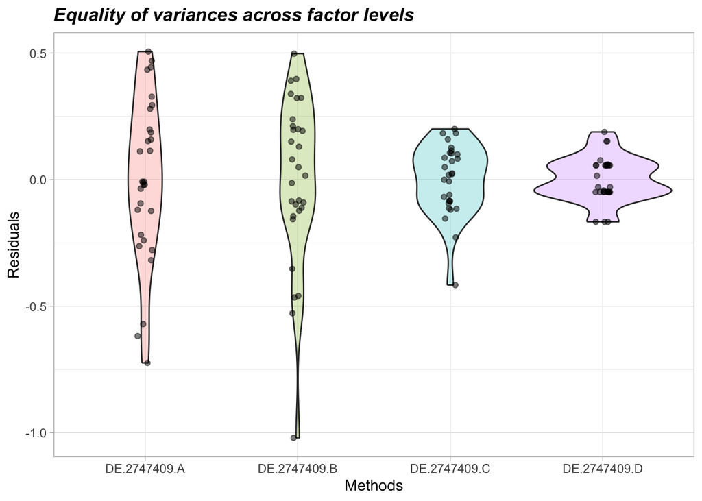

```r
# 2) Equality of variances across factor levels (homoscedasticity)

## As the results for Fligner–Killeen test show significance (p = 1.312e-06) and residual distribution plot demonstrates difference in the spread of residuals across method groups, the assumption for homoscedasticity seems to be violated.

fligner.test(Value ~ Method, data = myres)
##
##  Fligner-Killeen test of homogeneity of variances
##
## data:  Value by Method
## Fligner-Killeen:med chi-squared = 30.104, df = 3, p-value = 1.312e-06

## Visualisation of variances across factor levels

myres %>%
  ggplot(aes(x = Method, y = mytest_residual)) +
  geom_violin(aes(fill = Method), alpha = 0.25, show.legend = FALSE) +
  geom_jitter(width = .05, alpha = 0.5) +
  theme_light() +
  ggtitle("Equality of variances across factor levels")+
  theme(plot.title = element_text(face = "bold.italic"))+
  xlab("Methods") + ylab("Residuals") +
  theme(strip.text = element_text(colour = "black", face = "bold.italic"))
```

```r
# 3) Independence of model residuals

## Since our experiment is designed to be executed independently with a separate random seed, dependence of the residuals is not expected.
```

### 1.1.f

Perform a post-hoc Tukey test, using the multcomp package. Store the object returned by the function that executes the Tukey test in variable `myMHT1`. Use the `summary()` function to inspect the results of these comparisons.

```r
# ADD YOUR CODE HERE

# Post-hoc Tukey test
## Since the Tukey test results are significant (p < 1e-06) and residual distribution plot demonstrates difference in the spread of residuals across method groups, it is reasonable to say that all of the methods show significantly different mean performances. Although Method C showed the highest mean response, followed by Methods B and A, whereas Method D showed the lowest mean response, since the smaller values of the mean loss function corresponds to better performance, Method D showed the best performance (i.e. the smallest mean loss). However, this is reliable when all the assumptions for the ANOVA test are met. As we have encountered violation of the homoscedasticity assumption, post-hoc test that does not require the assumption of equal residual variance across the method groups such as the Games-Howell test could be conducted.

myMHT1 <- glht(mytest01, linfct = mcp(Method = "Tukey"))
summary(myMHT1)
##
##   Simultaneous Tests for General Linear Hypotheses
##
## Multiple Comparisons of Means: Tukey Contrasts
##
##
## Fit: aov(formula = Value ~ Method, data = myres)
##
## Linear Hypotheses:
##                                  Estimate Std. Error t value Pr(>|t|)
## DE.2747409.B - DE.2747409.A == 0  0.60605    0.06252   9.694  < 1e-07 ***
## DE.2747409.C - DE.2747409.A == 0  0.97183    0.06252  15.545  < 1e-07 ***
## DE.2747409.D - DE.2747409.A == 0 -0.93120    0.06252 -14.895  < 1e-07 ***
## DE.2747409.C - DE.2747409.B == 0  0.36579    0.06252   5.851 1.35e-07 ***
## DE.2747409.D - DE.2747409.B == 0 -1.53724    0.06252 -24.589  < 1e-07 ***
## DE.2747409.D - DE.2747409.C == 0 -1.90303    0.06252 -30.440  < 1e-07 ***
## ---
## Signif. codes:  0 '***' 0.001 '**' 0.01 '*' 0.05 '.' 0.1 ' ' 1
## (Adjusted p values reported -- single-step method)

## (DON'T FORGET THAT YOUR OUTPUT OBJECT SHOULD BE STORED IN A VARIABLE CALLED
## myMHT1).
```

Extract the simultaneous confidence intervals of your Tukey test comparisons using function `confint()`, using the confidence level indicated by your specific experimental parameters. Store the object returned by `confint()` into a variable called myCIs02. Echo this object and inspect the table of confidence intervals.

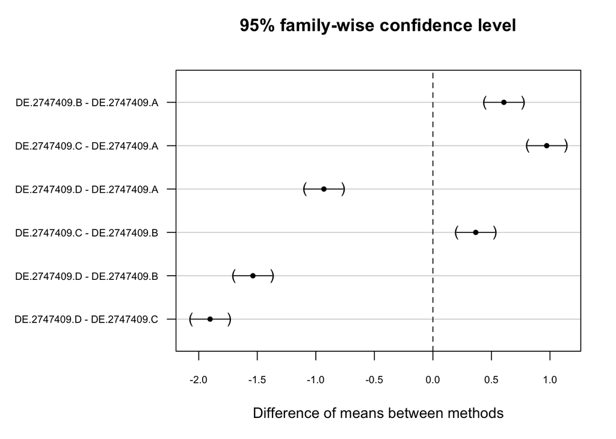

```r
# ADD YOUR CODE HERE
conf.level = 1 - alpha

## None of the confidence intervals derived from Tukey’s test include zero, indicating that all pairwise mean differences shown in between methods are statistically significant.

myCIs02 <- confint(myMHT1, level = conf.level)
myCIs02
##
##   Simultaneous Confidence Intervals
##
## Multiple Comparisons of Means: Tukey Contrasts
##
##
## Fit: aov(formula = Value ~ Method, data = myres)
##
## Quantile = 2.6098
## 95% family-wise confidence level
##
##
## Linear Hypotheses:
##                                  Estimate lwr     upr
## DE.2747409.B - DE.2747409.A == 0  0.6060   0.4429  0.7692
## DE.2747409.C - DE.2747409.A == 0  0.9718   0.8087  1.1350
## DE.2747409.D - DE.2747409.A == 0 -0.9312  -1.0944 -0.7680
## DE.2747409.C - DE.2747409.B == 0  0.3658   0.2026  0.5289
## DE.2747409.D - DE.2747409.B == 0 -1.5372  -1.7004 -1.3741
## DE.2747409.D - DE.2747409.C == 0 -1.9030  -2.0662 -1.7399

## Confidence intervals of the difference of means

par(mar = c(5, 10, 4, 2))
plot(myCIs02, xlab = "Difference of means between methods",cex.axis = 0.7)
```

```r
## (DON'T FORGET THAT YOUR OUTPUT OBJECT SHOULD BE STORED IN A VARIABLE CALLED
## myCIs02).
```

### 1.1.g

Based on your point estimates obtained in item 1.1.c, what is the method that presents the best (i.e., the smallest) mean loss? Set the variable `best_method` below with the name of that method:

```r
# ADD YOUR CODE HERE

## Tukey pairwise mean differences show the minimised loss ordering of Method D > A > B > C. (smaller = better)
myMHT1_Summary <- sort(summary(myMHT1)$test$coefficients)

pairwise_contrast_summary <- data_frame(
  Pairwise_difference = names(myMHT1_Summary),
  Estimate = as.numeric(myMHT1_Summary)
)
## Warning: `data_frame()` was deprecated in tibble 1.1.0.
## ℹ Please use `tibble()` instead.
## This warning is displayed once every 8 hours.
## Call `lifecycle::last_lifecycle_warnings()` to see where this warning was
## generated.

pairwise_contrast_summary
## # A tibble: 6 × 2
##   Pairwise_difference         Estimate
##   <chr>                          <dbl>
## 1 DE.2747409.D - DE.2747409.C   -1.90
## 2 DE.2747409.D - DE.2747409.B   -1.54
## 3 DE.2747409.D - DE.2747409.A   -0.931
## 4 DE.2747409.C - DE.2747409.B    0.366
## 5 DE.2747409.B - DE.2747409.A    0.606
## 6 DE.2747409.C - DE.2747409.A    0.972

## Method-wise mean loss also shows the minimised loss ordering of Method D > A > B > C.
method_loss_summary <- myres %>%
  group_by(Method) %>%
  summarise(mean_loss = mean(Value), .groups = "drop") %>%
  arrange(mean_loss)

method_loss_summary
## # A tibble: 4 × 2
##   Method       mean_loss
##   <fct>            <dbl>
## 1 DE.2747409.D      2.25
## 2 DE.2747409.A      3.18
## 3 DE.2747409.B      3.78
## 4 DE.2747409.C      4.15

## Hence, the method that presents the best (i.e. the smallest) mean loss would be Method D.
best_method <- as.character(method_loss_summary$Method[1])

best_method
## [1] "DE.2747409.D"

## (DON'T FORGET THAT THE *NAME* OF THE BEST METHOD BASED ON THE POINT ESTIMATE OF THE MEAN SHOULD BE STORED IN A VARIABLE CALLED best_method).
```

Based on the CIs you calculated after the Tukey tests, what is the confidence interval on the difference of the means between the best Method Above and the second-best one? Store your confidence interval in a single-row dataframe called `topComparison`, with the following columns:

- `Method1` (containing the name of the best method that you identified above)
- `Method2` (containing the name of the second-best method)
- `DiffMeans` (containing the estimated difference of means)
- `CI.lower` (containing the estimated lower bound of the confidence interval)
- `CI.upper` (containing the estimated upper bound of the confidence interval)

```r
# ADD YOUR CODE HERE

CI_02 <- myCIs02$confint

CI_02
##                               Estimate        lwr        upr
## DE.2747409.B - DE.2747409.A  0.6060466  0.4428847  0.7692086
## DE.2747409.C - DE.2747409.A  0.9718323  0.8086703  1.1349942
## DE.2747409.D - DE.2747409.A -0.9311953 -1.0943572 -0.7680334
## DE.2747409.C - DE.2747409.B  0.3657856  0.2026237  0.5289476
## DE.2747409.D - DE.2747409.B -1.5372419 -1.7004039 -1.3740800
## DE.2747409.D - DE.2747409.C -1.9030276 -2.0661895 -1.7398656
## attr(,"conf.level")
## [1] 0.95
## attr(,"calpha")
## [1] 2.60983

second_method <- as.character(method_loss_summary$Method[2])

first_pw_diff <- paste(best_method, "-", second_method)
second_pw_diff <- paste(second_method, "-", best_method)

if (first_pw_diff %in% rownames(CI_02)) {
  row   <- CI_02[first_pw_diff, ]
  diff  <- row["Estimate"]
  lower <- row["lwr"]
  upper <- row["upr"]
} else if (second_pw_diff %in% rownames(CI_02)) {
  row   <- CI_02[second_pw_diff, ]
  diff  <- -row["Estimate"]
  lower <- -row["upr"]
  upper <- -row["lwr"]
}

topComparison <- data.frame(
  Method1  = best_method,
  Method2  = second_method,
  DiffMeans = as.numeric(diff),
  CI.lower  = as.numeric(lower),
  CI.upper  = as.numeric(upper)
)

topComparison
##        Method1      Method2  DiffMeans  CI.lower   CI.upper
## 1 DE.2747409.D DE.2747409.A -0.9311953 -1.094357 -0.7680334
## (DON'T FORGET TO STORE YOUR RESULTS AS A SINGLE-ROW DATAFRAME CALLED topComparison ).
```

Using the pooled estimate of the residual variance provided by the omnibus method (item 1.1.d) and the estimated difference of means of the top two methods, calculate the observed standardised effect size (Cohen’s d coefficient) between the best and second-best methods. Store this value as a variable called `CohenD`

```r
# ADD YOUR CODE HERE

omnibus_anova <- summary(mytest01)

## Pooled residual variance (MSE)
sigma_sq_pooled <- omnibus_anova[[1]]["Residuals", "Mean Sq"]

## Pooled residual standard deviation
sigma_pooled <- sqrt(sigma_sq_pooled)

# Difference of means between best and second-best methods.
diff_means <- topComparison$DiffMeans

# Observed standardised effect size (Cohen's d coefficient)
## The observed standardised effect size (Cohen's d coefficient = -3.85) and its magnitude (|d|) being much larger than predefined MRES (0.9) indicate that Method D performs significantly better than Method A by achieving a lower mean loss.
CohenD <- diff_means / sigma_pooled
CohenD
## [1] -3.845817

## (DON'T FORGET TO STORE YOUR RESULTS AS A NUMERIC VARIABLE CALLED CohenD ).
```

Provide a brief comment (up to 150 words) on whether the best method (in terms of point estimate of mean loss) was significantly better than the second-best one at your predefined significance level, and comparing the observed value of the Cohen’s D coefficient with the miminally relevant effect size indicated in your experimental parameters, $d*$

At the predefined significance level (alpha = 0.05), the best method (Method D) performs significantly better than the second-best method (Method A). Since the confidence intervals between Method D and A derived from Tukey’s test does not include zero, this indicates that the reduction in mean loss for Method D is statistically significant. Furthermore, the observed standardised effect size (Cohen’s d $\approx$ -3.85) and its magnitude (|d| $\approx$ 3.85) show that Method D achieves a much lower mean loss compared to Method A, corresponding to an extremely large performance difference. Since its magnitude is much larger than the desired minimally relevant effect size (MRES) (d* = 0.9), better performance of Method D over Method A is not only statistically significant but also practically relevant in this experiment.

## Question 1.2

### 1.2.a

Enter the statistical hypotheses of your initial (omnibus) test in for this task the text block below. Provide a brief (less than 150 words) description of what is being tested.

Our objective now is to compare the mean loss of the optimisation methods across multiple test problems, rather than on a single problem under repeated runs. We still use the F-statistic from one-way ANOVA to test whether the variability in mean loss between methods across problems is significantly greater than the variability within method groups, under the null hypothesis that all methods have the same expected loss. Thus, rejecting the null hypothesis provides adequate statistical evidence that at least one method’s expected performance differs significantly from the others, thereby providing a rationale for conducting post-hoc tests to identify which method has the best expected performance for other problems belonging to the same class as the test ones.

$$\begin{cases}
H_0 &: \mu_i = \mu_j,\ \forall i, j \\
H_1 &: \exists\, i, j \text{ such that } \mu_i \ne \mu_j
\end{cases}$$

### 1.2.b

Based on the instructions provided in the coursework specs, calculate the required number of test problems necessary for your experiment to have the desired statistical properties. As a reminder, your experimental parameters are given by:

```
## Desired statistical parameters for your experimental design:
## ============================================================
## Significance level (alpha): alpha = 0.05
## Minimally relevant effect size (MRES): d* = 0.9
## Desired statistical power for MRES (desired power): (1-beta)* = 0.85
## Number of repeated runs for each method on each problem: nruns = 30
## ============================================================
```

Use the code block below to calculate your required number of problems, based on the experimental parameters above and the explicit instructions provided in the CW specs. Store your number of problems as a variable called `nprobs`.

```r
# ADD YOUR CODE HERE

# MRES is treated as delta when its scale is standardized (sd = 1).
MRES <- exp_pars$mres
des_power <- exp_pars$desired.power
num_methods <- length(method.names)
# Number of pairwise all-vs-one comparisons with the reference.
num_comparison <- num_methods - 1

# For significance level, divide alpha by the number of pairwise comparisons with the reference to maintain the family-wise error rate (FWER) at a controlled level.
power_calculation <- power.t.test(delta = MRES, sd = 1, sig.level = alpha / num_comparison, power = des_power, type = "paired", alternative = "two.sided")

nprobs <- ceiling(power_calculation$n)
nprobs
## [1] 18
## (DON'T FORGET TO STORE YOUR RESULT AS A VARIABLE CALLED nprobs).
```

### 1.2.c

The names of the problems you should use for this item are automatically generated and stored in a variable called `problem.names`. The dimensions of each test problem are stored in a variable called `problem.dimensions`.

Here’s an example of how to generate a single observation for your first method on the first test problem `problem.names[1]`:

```r
## DO NOT CHANGE ANYTHING IN THIS CODE BLOCK
x <- ExpDE2(method.name = method.names[1], problem.name = problem.names[1])
my_obs <- log(x)
my_obs
## [1] 2.576541
```

Adapt the code above to generate your experimental observations. The number of problems is defined by your `nprobs` and the number of repeated runs of each method on each problem is defined in your experimental parameters (nruns). Store your observations in a tidy data frame named `myres2`, containing one observation per row and the following columns:

- `Method` (containing the method name)
- `Problem` (containing the problem name)
- `Problem_type` (containing the problem type)
- `Problem_dimension` (containing the problem dimension)
- `Value` (containing the observation)

Set the first three columns as **factor** variables. For column `Method`, set your reference method (the one defined as the best one in the preliminary tests, question 1.1.g) as the **reference** for that factor. The information on problem types and problem dimensions is available in vectors `problem.types` and `problem.dimensions`, respectively.

Your data frame `myres2` should have (nprobs x nruns x number of methods) rows

```r
set.seed(MY_STUDENT_ID) ## <--- DO NOT CHANGE THIS LINE

# ADD YOUR CODE HERE

myres2<- lapply(seq_along(problem.names),\(p){
  lapply(seq_along(method.names),\(m){

    obs <- replicate(nruns,log(ExpDE2(method.name = method.names[m],
                                    problem.name = problem.names[p])))

    data.frame(Method = factor(method.names[m]),
               Problem = factor(problem.names[p]),
               Problem_type = factor(problem.types[p]),
               Problem_dimension = problem.dimensions[p],
               Value = obs)
    }) %>%
    bind_rows()
  }) %>%
  bind_rows()

myres2$Method = relevel(myres2$Method, ref = best_method)

# Example of the first 6 rows in actual "myres2" data frame (2160 × 5).
head(myres2)
##         Method        Problem Problem_type Problem_dimension    Value
## 1 DE.2747409.A Prob.2747409.1    rastrigin                14 1.898569
## 2 DE.2747409.A Prob.2747409.1    rastrigin                14 2.937016
## 3 DE.2747409.A Prob.2747409.1    rastrigin                14 3.431111
## 4 DE.2747409.A Prob.2747409.1    rastrigin                14 2.608906
## 5 DE.2747409.A Prob.2747409.1    rastrigin                14 2.647891
## 6 DE.2747409.A Prob.2747409.1    rastrigin                14 2.344028

## (DON'T FORGET THAT YOUR OBSERVATIONS SHOULD BE STORED IN A DATA FRAME CALLED
## myres2 WITH THE STRUCTURE DESCRIBED ABOVE).
```

### 1.2.d Statistical testing

Use the code block below to perform the adequate statistical test, according to the instructions of the coursework descriptor. Store the statistical test object in a variable called `mytest02`, and use the `summary()` function to print the results.

```r
# ADD YOUR CODE HERE

mytest02 <- aov(Value ~ Method, data = myres2)
summary(mytest02)
##               Df Sum Sq Mean Sq F value Pr(>F)
## Method         3  295.2   98.40   184.7 <2e-16 ***
## Residuals   2156 1148.6    0.53
## ---
## Signif. codes:  0 '***' 0.001 '**' 0.01 '*' 0.05 '.' 0.1 ' ' 1

## (DON'T FORGET THAT THE OBJECT RETURNED BY THE STATISTICAL TEST FUNCTION
## SHOULD BE STORED IN A VARIABLE CALLED mytest02).
```

### 1.2.e

Perform a post-hoc Dunnett test, using the multcomp package. Store the object returned by the function that executes the Dunnett test in variable `myMHT2`. Use the `summary()` function to inspect the results of these comparisons.

```r
# ADD YOUR CODE HERE

myMHT2 <- glht(mytest02, linfct = mcp(Method = "Dunnett"))
summary(myMHT2)
##
##   Simultaneous Tests for General Linear Hypotheses
##
## Multiple Comparisons of Means: Dunnett Contrasts
##
##
## Fit: aov(formula = Value ~ Method, data = myres2)
##
## Linear Hypotheses:
##                                  Estimate Std. Error t value Pr(>|t|)
## DE.2747409.A - DE.2747409.D == 0  0.06491    0.04442   1.461    0.327
## DE.2747409.B - DE.2747409.D == 0  0.53589    0.04442  12.064   <1e-04 ***
## DE.2747409.C - DE.2747409.D == 0  0.90794    0.04442  20.440   <1e-04 ***
## ---
## Signif. codes:  0 '***' 0.001 '**' 0.01 '*' 0.05 '.' 0.1 ' ' 1
## (Adjusted p values reported -- single-step method)

## (DON'T FORGET THAT YOUR OUTPUT OBJECT SHOULD BE STORED IN A VARIABLE CALLED
## myMHT2).
```

Extract the simultaneous confidence intervals of your Dunnett test comparisons using function `confint()`, using the confidence level indicated by your specific experimental parameters. Store the object returned by `confint()` into a variable called myCIs03. Echo this object and inspect the table of confidence intervals.

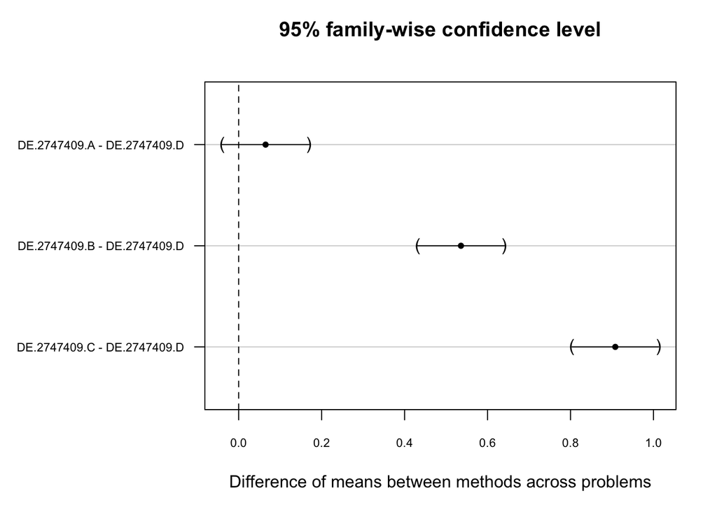

```r
# ADD YOUR CODE HERE

myCIs03 <- confint(myMHT2, level = conf.level)
myCIs03
##
##   Simultaneous Confidence Intervals
##
## Multiple Comparisons of Means: Dunnett Contrasts
##
##
## Fit: aov(formula = Value ~ Method, data = myres2)
##
## Quantile = 2.3493
## 95% family-wise confidence level
##
##
## Linear Hypotheses:
##                                  Estimate lwr      upr
## DE.2747409.A - DE.2747409.D == 0  0.06491 -0.03945  0.16926
## DE.2747409.B - DE.2747409.D == 0  0.53589  0.43153  0.64024
## DE.2747409.C - DE.2747409.D == 0  0.90794  0.80358  1.01229

## Confidence intervals of the difference of means

par(mar = c(5, 10, 4, 2))
plot(myCIs03, xlab = "Difference of means between methods across problems",cex.axis = 0.7)
```

```r
## (DON'T FORGET THAT YOUR OUTPUT OBJECT SHOULD BE STORED IN A VARIABLE CALLED
## myCIs03).
```

### 1.2.f

Based on your results, which of the methods would recommend as the selected strategy for your company’s needs? Is it the same one as the preliminary test indicated? Is there a second-best that is close enough to be worth mentioning? Use the text block below and add your comments on the results of this experiment (up to 300 words)

Our aim in this experiment was to determine whether there is a significant difference in performance between the methods across problems and to identify which method should be recommended for the company to adopt. Based on the initial analysis conducted with one-way ANOVA and an extended analysis conducted with a post-hoc Dunnett test, Method D had the lowest mean loss among the four methods.

From the results of Dunnett test, the contrasts among the methods using Method D as the reference showed that Methods B and C had significantly larger mean losses than Method D. The fact that their estimated mean loss differences are comparatively large (estimate $\approx$ 0.5 & 0.9) and statistically significant that there is a difference among the means (p < 1e-04) provides strong evidence that they are statistically and practically worse than Method D, thus not recommended for the company to consider.

Based on the results obtained, Method D will still remain as the best method to be recommended as it has the smallest estimated mean loss. However, after the further test conducted, Method A appears to be a competitive alternative to Method D. Hence, it could be considered as a second best method when it has other advantages under real world constraints compared to Method D.

Enter the name of your final method recommendation (“best method”) as variable `best_final` below

```r
# ADD YOUR CODE HERE

best_final <- "DE.2747409.D"

## (DON'T FORGET THAT THE NAME OF THE BEST METHOD SHOULD BE STORED AS VARIABLE
## best_final).
```

### =========== End of Task I ===========